# BCM Simulation Results

Caitlin Ward

## Gelman Rubin

Number of models remaining with Gelman Rubin > 1.1.

```
## , ,  = 14,  = fixed
##
##
##          betatSpline gp spline thresh
##   hill             1  0      0      0
##   power            6  0      1      0
##   thresh           4  1      0      0
##
## , ,  = 30,  = fixed
##
##
##          betatSpline gp spline thresh
##   hill             0  0      1      0
##   power            3  0      3      0
##   thresh           1  0      5      2
```

## Posterior parameter estimates

When correct parametric model was fit to the true data generation process.

### Threshold Alarm

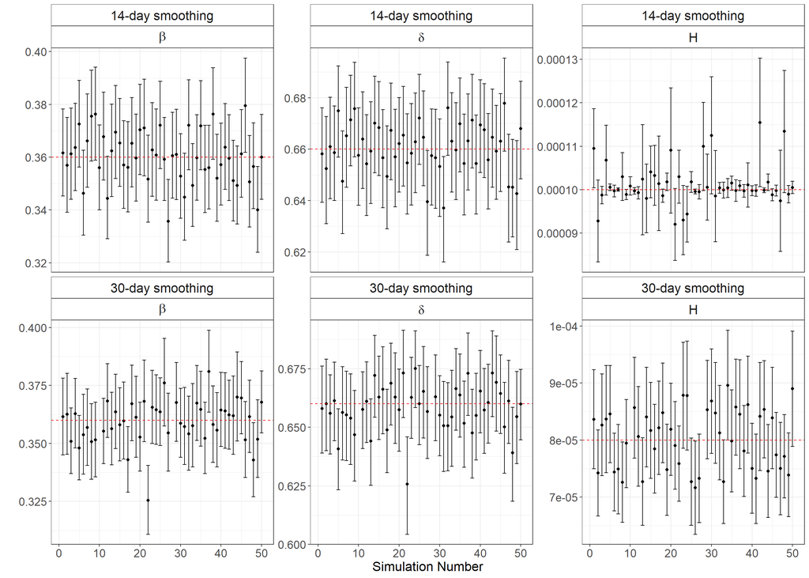

### Hill Alarm

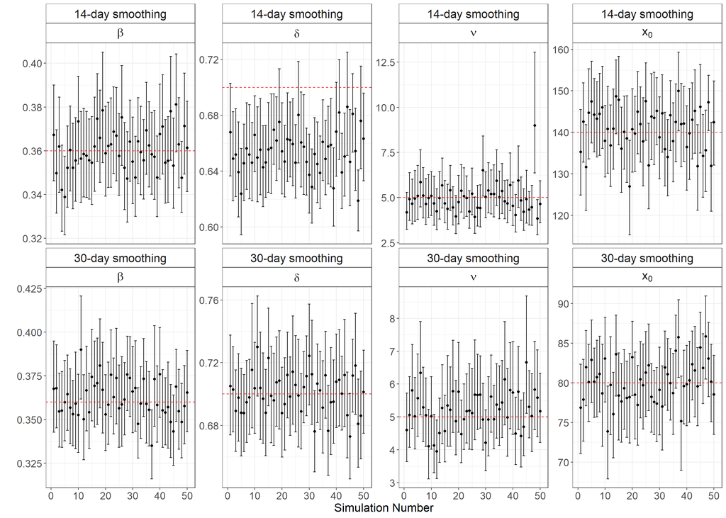

### Power Alarm

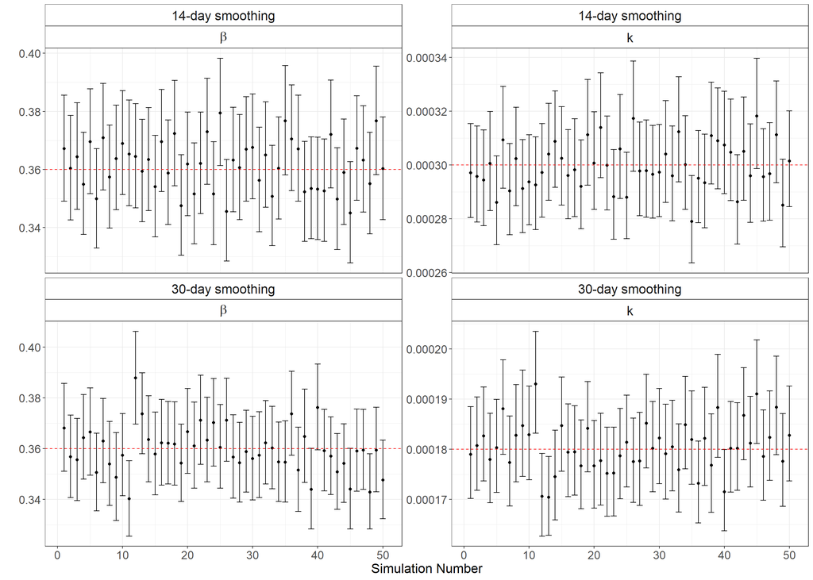

## Posterior for Alarm Function

### 14-day Smoothing Window

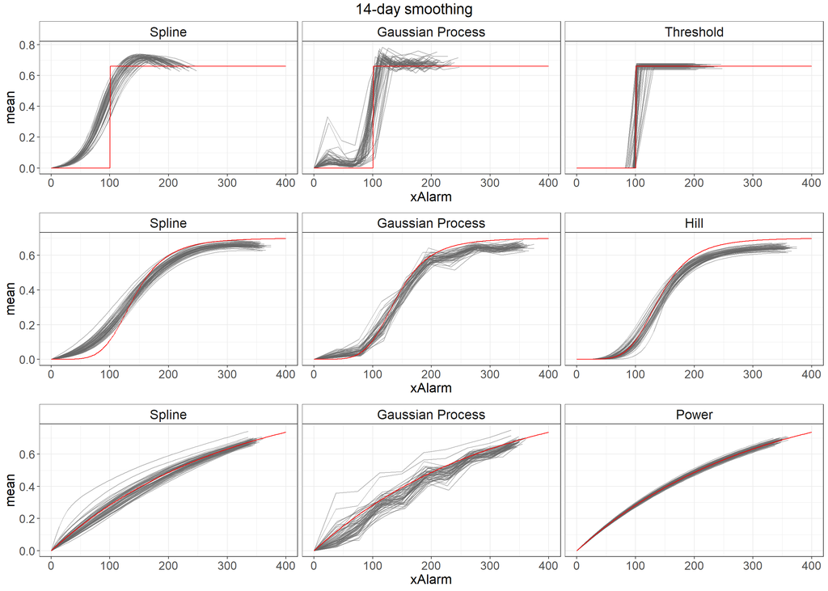

### 30-day Smoothing Window

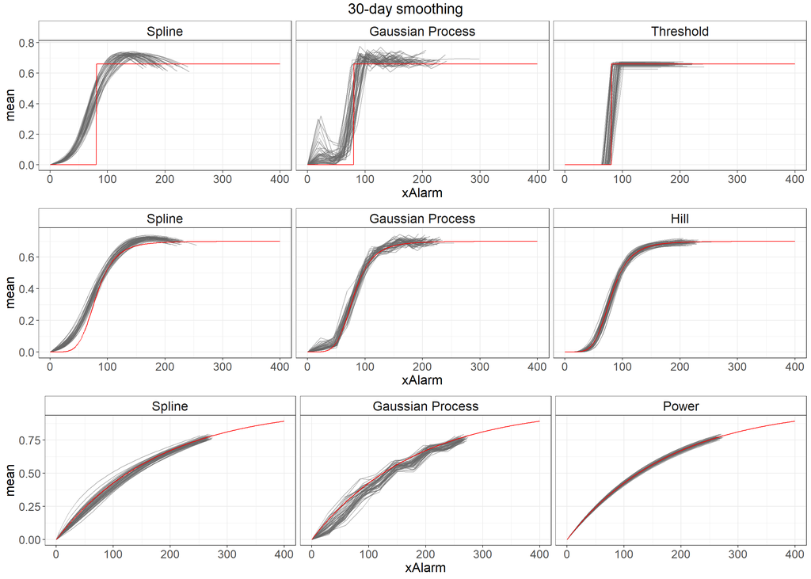

## Posterior prediction

Difficult to look at for every simulated epidemic. Shown here for first epidemic from each scenario.

### 14-day Smoothing Window

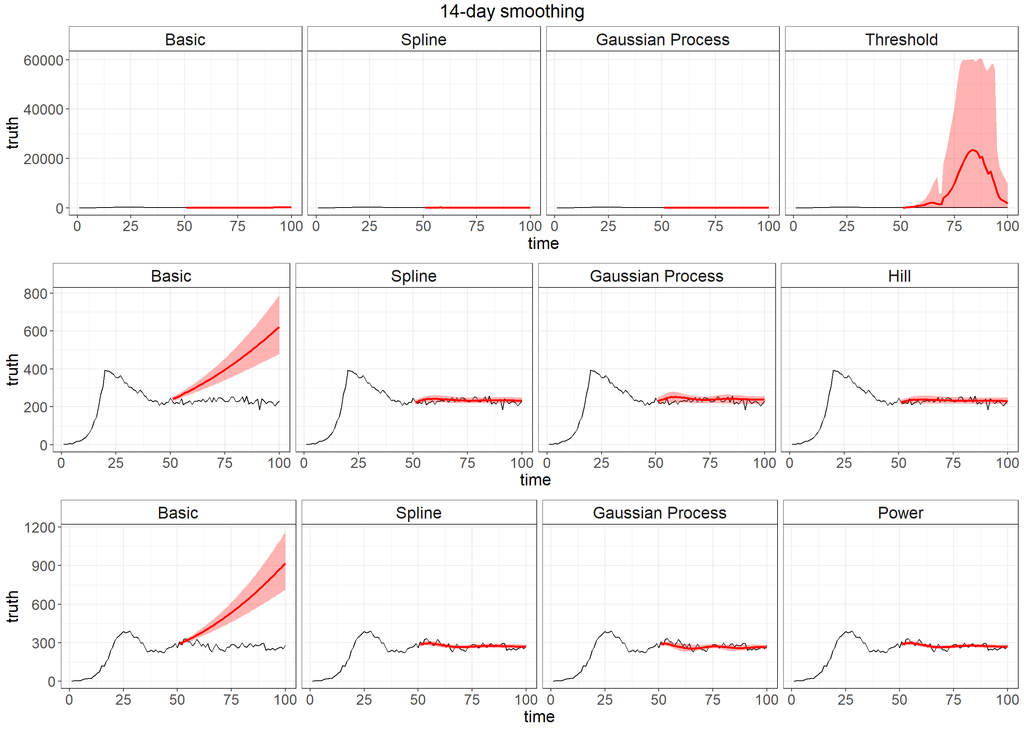

### 30-day Smoothing Window

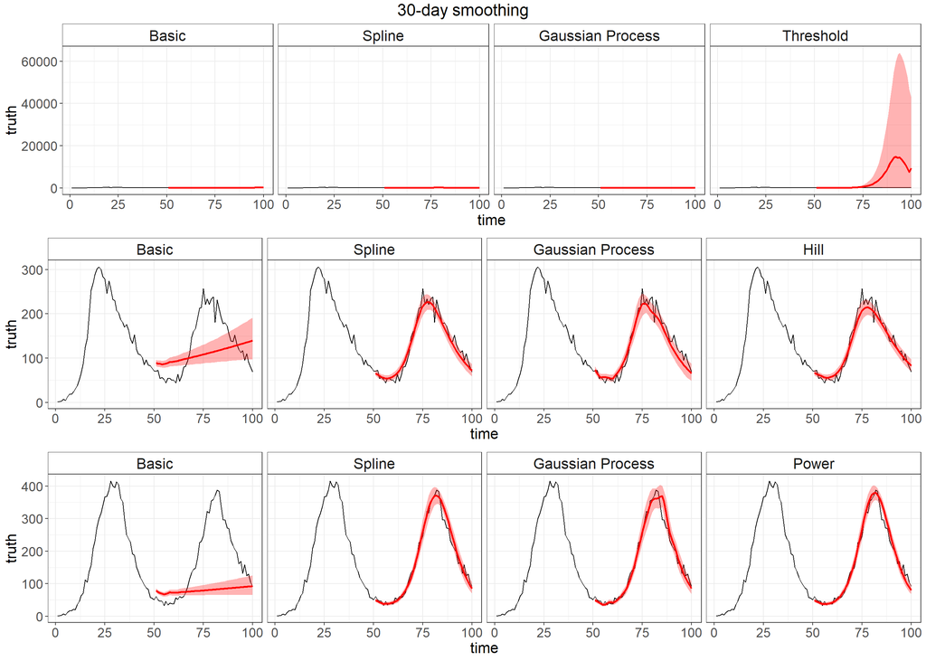

Now for second simulated epidemic

### 14-day Smoothing Window

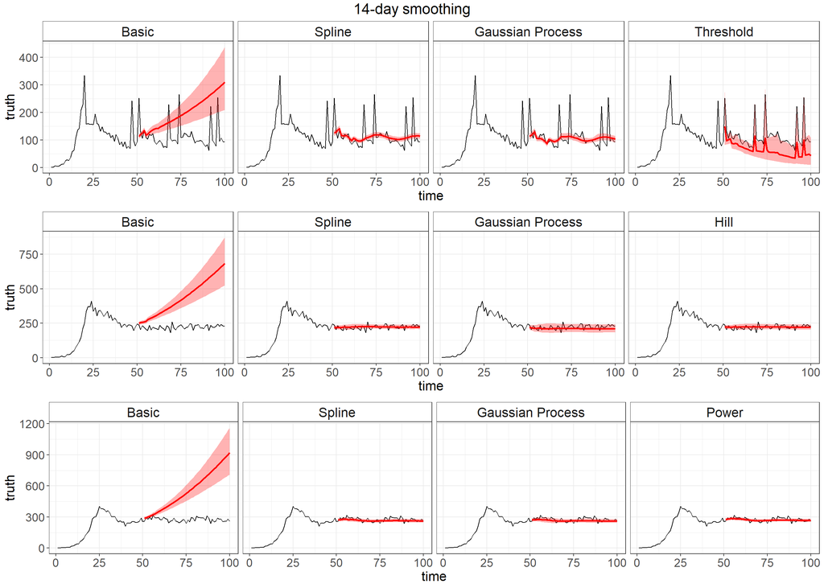

### 30-day Smoothing Window

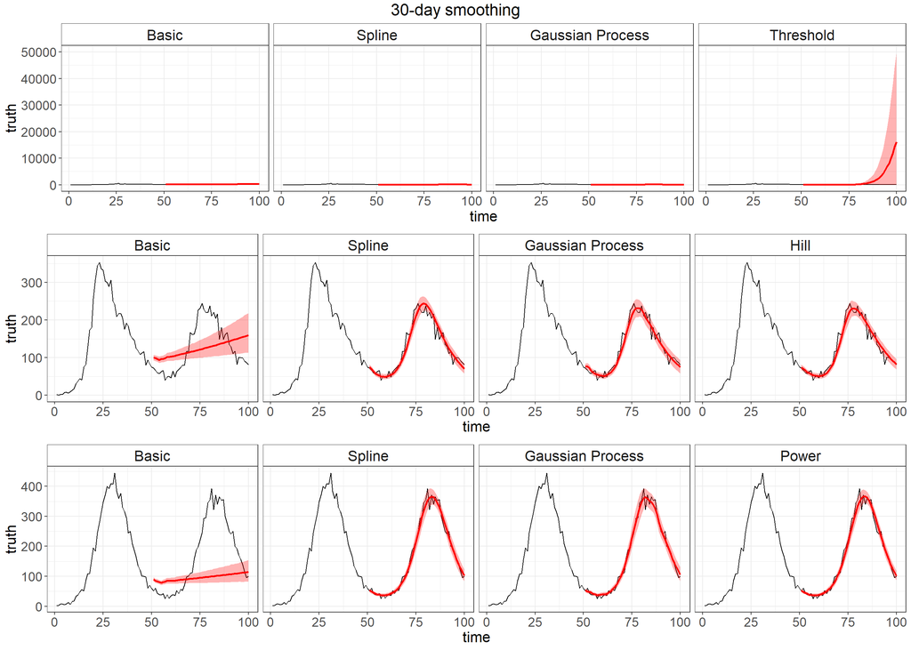

## Posterior for beta[t] when modeled explicitly

For one simulation.

$\beta_t = \beta (1 - a_t)$

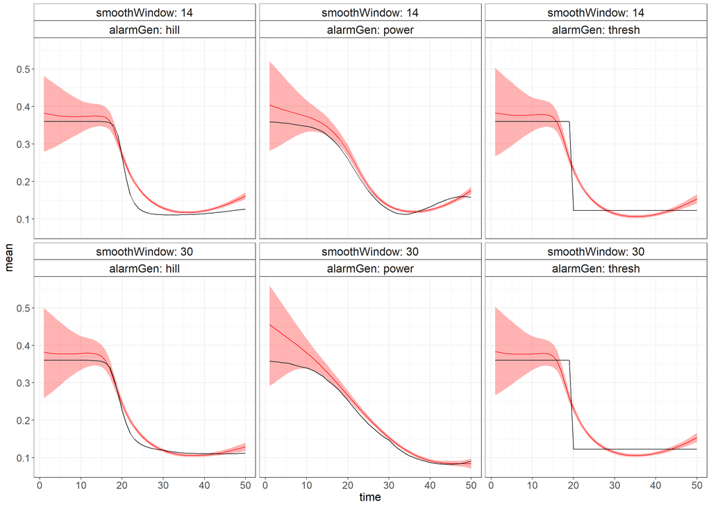

And for another simulation

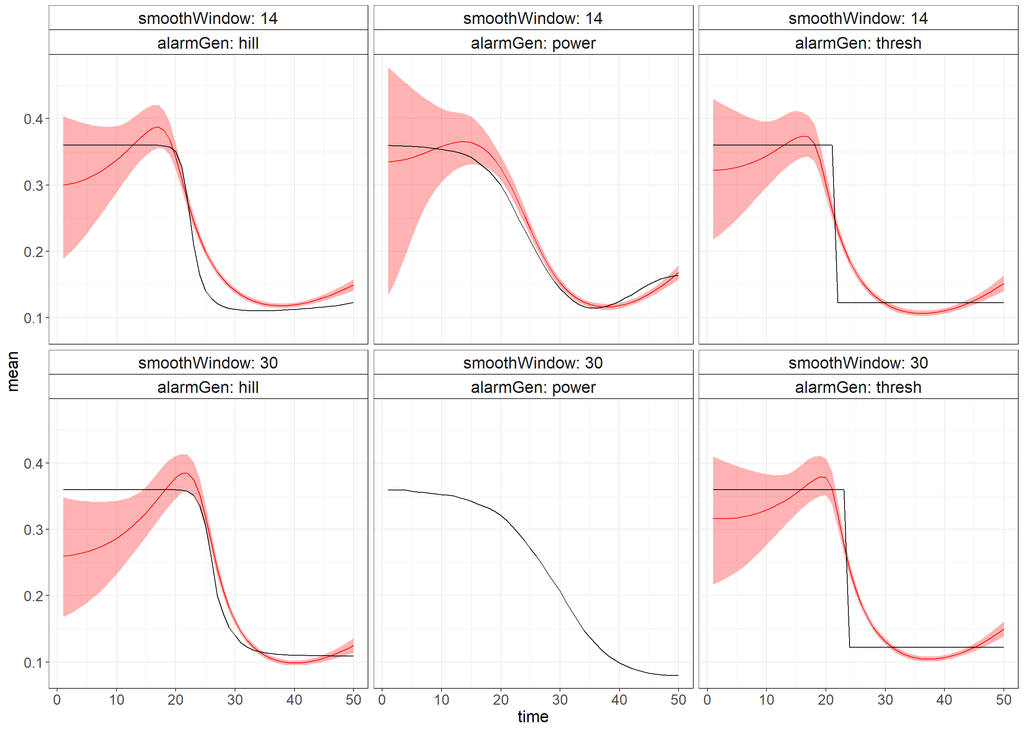

## WAIC comparisons

### WAIC Summaries

WAIC (introduced by Watanabe, 2010, who calls it the widely applicable information criterion) is a more fully Bayesian approach for estimating the out-of-sample expectation (2), starting with the computed log pointwise posterior predictive density (5) and then adding a correction for effective number of parameters to adjust for overfitting.

WAIC = -2(lppd - pWAIC)

= -2lppd + 2pWAIC

WAIC: The computed WAIC, on the deviance scale. Smaller values are better when comparing WAIC for two models.

lppd: The log predictive density component of WAIC. Bigger is better.

pWAIC: The pWAIC estimate of the effective number of parameters, computed using the pWAIC2 method of Gelman et al. (2014).

$pWAIC_2 = \sum_{i = 1}^n \text{Var}_{post} \log p(y_i|\theta)$

we compute the posterior variance of the log predictive density for each data point

#### Threshold alarm with 14-day smoothing window

| alarmFit | mean_WAIC | mean_lppd | mean_pWAIC |
| --- | --- | --- | --- |
| thresh | 357.1777 | -176.6373 | 1.95153 |
| gp | 461.7447 | -209.9198 | 20.95252 |
| spline | 571.4836 | -260.0829 | 25.65891 |
| betatSpline | 758.2528 | -328.4823 | 50.64409 |
| basic | 1613.1232 | -775.8533 | 30.70834 |

#### Threshold alarm with 30-day smoothing window

| alarmFit | mean_WAIC | mean_lppd | mean_pWAIC |
| --- | --- | --- | --- |
| thresh | 358.3231 | -177.2377 | 1.923783 |
| gp | 432.3158 | -192.1599 | 23.997957 |
| spline | 552.8494 | -247.3765 | 29.048177 |
| betatSpline | 706.6160 | -309.6122 | 43.695767 |
| basic | 1723.3522 | -827.1245 | 34.551612 |

#### Hill alarm with 14-day smoothing window

| alarmFit | mean_WAIC | mean_lppd | mean_pWAIC |
| --- | --- | --- | --- |
| hill | 380.1203 | -186.2599 | 3.800236 |
| spline | 385.6947 | -188.1483 | 4.699098 |
| gp | 388.5626 | -186.3850 | 7.896274 |
| betatSpline | 468.4229 | -220.3053 | 13.906111 |
| basic | 1665.1251 | -807.9005 | 24.662042 |

#### Hill alarm with 30-day smoothing window

| alarmFit | mean_WAIC | mean_lppd | mean_pWAIC |
| --- | --- | --- | --- |
| hill | 365.1272 | -178.7364 | 3.827233 |
| gp | 373.8793 | -178.6194 | 8.320197 |
| spline | 375.5365 | -182.7436 | 5.024662 |
| betatSpline | 407.8509 | -194.7391 | 9.186327 |
| basic | 1626.2277 | -786.5200 | 26.593902 |

#### Power alarm with 14-day smoothing window

| alarmFit | mean_WAIC | mean_lppd | mean_pWAIC |
| --- | --- | --- | --- |
| power | 374.8745 | -185.5084 | 1.928801 |
| spline | 376.7722 | -184.4279 | 3.958203 |
| gp | 386.3302 | -184.7543 | 8.410827 |
| betatSpline | 391.7929 | -188.9262 | 6.970273 |
| basic | 1385.1405 | -671.6355 | 20.934766 |

#### Power alarm with 30-day smoothing window

| alarmFit | mean_WAIC | mean_lppd | mean_pWAIC |
| --- | --- | --- | --- |
| power | 366.2401 | -181.1506 | 1.969403 |
| spline | 368.0988 | -179.9811 | 4.068272 |
| betatSpline | 377.0808 | -182.4018 | 6.138599 |
| gp | 380.2675 | -180.6890 | 9.444755 |
| basic | 1871.4239 | -902.8262 | 32.885727 |

### WAIC Model Selection

#### 14-day smoothing window

|  | thresh | hill | power |
| --- | --- | --- | --- |
| thresh | 100.0% | 0.0% | 0.0% |
| hill | 0.0% | 92.0% | 0.0% |
| power | 0.0% | 0.0% | 82.0% |
| gp | 0.0% | 2.0% | 2.0% |
| spline | 0.0% | 6.0% | 12.0% |
| betatSpline | 0.0% | 0.0% | 4.0% |
| basic | 0.0% | 0.0% | 0.0% |

#### 30-day smoothing window

|  | thresh | hill | power |
| --- | --- | --- | --- |
| thresh | 96.0% | 0.0% | 0.0% |
| hill | 0.0% | 92.0% | 0.0% |
| power | 0.0% | 0.0% | 88.0% |
| gp | 4.0% | 2.0% | 2.0% |
| spline | 0.0% | 6.0% | 10.0% |
| betatSpline | 0.0% | 0.0% | 0.0% |
| basic | 0.0% | 0.0% | 0.0% |